# FTICR_Data_Visualizations

2025-01-27

## Get data ready for analysis

### Read in the data

Read-in Processed MONet FTICR-MS and Biogeochemistry data. The FTICR-MS steps below are the same ones on the FTICR_Processing.Rmd file.

### Initial cleaning

Step 1 is to split this file into two: (a) `mol` file, which has info for each molecule/peak; and (b) `dat` file, which has data about the samples

### Create molecular metadata file

This dataframe contains information pertaining to each peak, including the molecular formula and other molecular indices.  
We first select only the columns with atomic composition.

```r
mol =
  icr_report %>%
  dplyr::select(`Molecular.Formula`, C,H,O,N,P,S) %>%
  rename(molecular_formula = `Molecular.Formula`) %>%
  distinct()
```

Now, we want to process the `mol` file and calculate various indices

1. indices
- AImod (aromatic index), calculated based on [Koch and Dittmar (2016)](https://doi.org/10.1002/rcm.7433)
- NOSC (nominal oxidation state of carbon), calculated based on [Riedel et al. 2012](https://doi.org/10.1021/es203901u)
- GFE (Gibbs Free Energy of carbon oxidation), calculated from NOSC, as per [LaRowe & Van Cappellen 2011](https://doi.org/10.1016/j.gca.2011.01.020)
- H/C, or the ratio of hydrogen to carbon in the molecule
- O/C, or the ratio of oxygen to carbon in the molecule

```r
mol =
  mol %>%
  mutate(across(c("N","S","P"), ~replace_na(.,0)),
         AImod = round((1 + C - (0.5*O) - S - (0.5 * (N+P+H)))/(C - (0.5*O) - S - N - P), 4),
         AImod = ifelse(is.na(AImod), 0, AImod),
         AImod = ifelse(AImod == "Inf", 0, AImod),
         AImod = ifelse(AImod == "-Inf", 0, AImod),
         NOSC =  round(4-(((4*C) + H - (3*N) - (2*O) - (2*S))/C), 4),
         GFE = 60.3-(28.5 * NOSC),
         HC = round(H/C, 2),
         OC = round(O/C, 2)
  )
```

2. Elemental class

We can also group the molecules based on the elemental composition, i.e. “CHO”, “CHONS”, “CHONP”, “CHONPS” classes

```r
mol =
  mol %>%
  mutate(
    El = str_remove_all(molecular_formula, "13C"),
    El = str_remove_all(El, "34S"),
    El = str_remove_all(El, "17O"),
    El = str_remove_all(El, "18O"),
    El = str_remove_all(El, "15N"),
    El = str_remove_all(El, "[0-9]"),
    El = str_remove_all(El, " "))
```

3. molecular class

Next, we assign classes (aromatic, aliphatic, etc.). These are Van Krevelen classes, typically assigned based on the H/C, O/C, and AImod indices. We calculate three sets of classes; users can use any of these, or assign their own classes as appropriate.

1. `Class1` from [Kim et al. 2003](https://doi.org/10.1021/ac034415p) uses H/C and O/C to classify molecules into “lipid”, “unsaturated hydrocarbon”, “protein”, “lignin”, “carbohydrate”, amino sugar”, “tannin”, and “condensed hydrocarbon”
2. `Class2` from [Seidel et al. 2014](https://doi.org/10.1016/j.gca.2014.05.038) uses H/C, O/C, and AImod to classify molecules into “aromatic”, “condensed aromatic”, “highly unsaturated compounds including polyphenols/lignins”, and “aliphatic”
3. `Class3` from [Seidel et al. 2017](https://doi.org/10.3389/feart.2017.00031) includes classes “aromatic”, “condensed aromatic”, “highly unsaturated compounds including polyphenols/lignins”, “carbohydrate”, “lipid”, “aliphatic”, and “aliphatic containing N”.

```r
mol =
  mol %>%
  mutate(
    Class1 = case_when(HC >= 1.55 & HC <= 2.25 & OC >= 0 & OC <= 0.3 ~ "Lipid",
                       HC >= 0.7 & HC <= 1.5 & OC >= 0.05 & OC <= 0.15 ~ "Unsat Hydrocarbon",
                       HC >= 1.45 & HC <= 2 & OC >= 0.3 & OC <= 0.55 ~ "Protein",
                       HC >= 0.81 & HC <= 1.45 & OC >= 0.28 & OC <= 0.65 ~ "Lignin",
                       HC >= 1.48 & HC <= 2.15 & OC >= 0.68 & OC <= 1 ~ "Carbohydrate",
                       HC >= 1.34 & HC <= 1.8 & OC >= 0.54 & OC <= 0.71 ~ "Amino Sugar",
                       HC >= 0.7 & HC <= 1.3 & OC >= 0.65 & OC <= 1.05 ~ "Tannin",
                       HC >= 0.3 & HC <= 0.81 & OC >= 0.12 & OC <= 0.7 ~ "Cond Hydrocarbon",
                       TRUE ~ "Other"),
    Class2 = case_when(AImod > 0.66 ~ "condensed aromatic",
                       AImod <= 0.66 & AImod > 0.50 ~ "aromatic",
                       AImod <= 0.50 & HC < 1.5 ~ "unsaturated/lignin",
                       HC >= 1.5 ~ "aliphatic"),
    Class2 = replace_na(Class2, "other"),
    Class3 = case_when(AImod > 0.66 ~ "condensed aromatic",
                       AImod <= 0.66 & AImod > 0.50 ~ "aromatic",
                       AImod <= 0.50 & HC < 1.5 ~ "unsaturated/lignin",
                       HC >= 2.0 & OC >= 0.9 ~ "carbohydrate",
                       HC >= 2.0 & OC < 0.9 ~ "lipid",
                       HC < 2.0 & HC >= 1.5 & N == 0 ~ "aliphatic",
                       HC < 2.0 & HC >= 1.5 & N > 0 ~ "aliphatic+N")
  )
```

### Create `dat` file

```r
dat =
  icr_report %>%
  dplyr::select(source, Molecular.Formula, Calculated.m.z, contains("Peak.Area")) %>%
  janitor::clean_names() %>%
  separate(source, sep = "_", into = c("icr", "Proposal_ID", "Sampling_Set", "Core_Section", "Rep")) %>%
  mutate(Rep = parse_number(Rep),
         sample_name = paste0(Proposal_ID, "_", Sampling_Set, "_", Core_Section)) %>%
  dplyr::select(-icr)
```

#### 3 acquisitions

Each sample contains a signal from 3 different instrument acquisitions, these need to be merged before we address extraction replicates.

```r
## acquisition reps

dat_acq =
  dat %>%
  mutate(peak_area_1 = case_when(peak_area_1 > 0 ~ 1),
         peak_area_2 = case_when(peak_area_2 > 0 ~ 1),
         peak_area_3 = case_when(peak_area_3 > 0 ~ 1),
         acquisition_count = peak_area_1 + peak_area_2 + peak_area_3,
         acquisition_KEEP = acquisition_count >= 2) %>%
  filter(acquisition_KEEP) %>%
  dplyr::select(-c(contains("peak_area"), contains("acquisition")))
```

#### 3 replicates

We have 3 extractions from each core section and site, the data from these extractions needs to be merged such that you can have one sample per site. Merge replicate extractions where you keep a molecular formula if it was present in at least 2 out of the 3 extraction replicates for that site and core location.

```r
## Now, we only select molecules that were identified in 2/3 of the total reps

max_replicates =
  dat_acq %>%
  dplyr::select(sample_name, Proposal_ID, Sampling_Set, Core_Section, Rep) %>%
  distinct() %>%
  group_by(sample_name, Proposal_ID, Sampling_Set, Core_Section) %>%
  dplyr::summarise(total_reps = n())


dat_reps =
  dat_acq %>%
  left_join(max_replicates) %>%
  group_by(Proposal_ID, Sampling_Set, Core_Section, molecular_formula) %>%
  dplyr::mutate(peak_reps = n()) %>%
  ungroup() %>%
  mutate(KEEP = peak_reps >= (2/3) * total_reps) %>%
  filter(KEEP) %>%
  dplyr::select(-KEEP)

dat_reps_keep =
  dat_reps %>%
  dplyr::select(-c(Rep, total_reps, peak_reps)) %>%
  distinct()
```

This is the list of all the peaks “present” (identified) in our samples.

Now, combine this file with the `mol` file we generated above.

```r
icr_processed =
  dat_reps_keep %>%
  left_join(mol)

names(icr_processed)
```

```
FALSE  [1] "Proposal_ID"       "Sampling_Set"      "Core_Section"
FALSE  [4] "molecular_formula" "calculated_m_z"    "sample_name"
FALSE  [7] "C"                 "H"                 "O"
FALSE [10] "N"                 "P"                 "S"
FALSE [13] "AImod"             "NOSC"              "GFE"
FALSE [16] "HC"                "OC"                "El"
FALSE [19] "Class1"            "Class2"            "Class3"
```

```r
wide_data = icr_processed %>%
  dplyr::select(-Proposal_ID,-Sampling_Set,-Core_Section,-calculated_m_z,
                -C,-H,-O,-N,-P,-S,-AImod,-NOSC,-GFE,
                -El,-Class1,-Class2,-Class3,-HC,-OC)

wide_data <- icr_processed %>%
  distinct(molecular_formula, sample_name) %>%  # Ensure unique combinations
   mutate(value = 1) %>%  # Create an auxiliary column for 1s
  pivot_wider(
    names_from = sample_name,
    values_from = value,
    values_fill = list(value = 0)  # Fill with 0s where there's no association
  )

merged_fticr_data = as.data.frame(wide_data)
row.names(merged_fticr_data) = merged_fticr_data$molecular_formula
row.names(mol) = mol$molecular_formula

merged_fticr_data = merged_fticr_data %>%
  dplyr::select(-molecular_formula)
```

### Additional Clean up for Data analysis

```r
# Extra cleaning if needed
# clean up missing peaks across all samples
#merged_fticr_data = merged_fticr_data[-which(rowSums(merged_fticr_data) == 0),]

# removing singletons (formulas found only in one site)
singletons = apply(merged_fticr_data, 1, function(x) length(which(x > 0))) # identify
merged_fticr_data = merged_fticr_data[-which(singletons == 1),]

# making sure the columns match in the mol file
mol <- mol[rownames(mol) %in% rownames(merged_fticr_data), ]
```

### Analyze data

##### H1: TOP layer will be richer (total number of peaks with MF assigned), more diverse and higher WEOM concentration than BTM layer.

#### Richness

Evaluate richness as the total number of molecular formula assigned within all top and bottom samples and do a boxplot where points are sample level total number of peaks categorically colors by top or bottom.

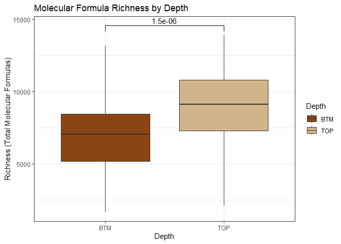

```r
# Perform t-test to compare richness between TOP and BTM
t_test_result <- t.test(total_formulas ~ Depth, data = mol_properties_average)

# Define colorblind-friendly soil colors
soil_colors <- c("TOP" = "#D2B48C", "BTM" = "#8B4513")  # Lighter brown for TOP, darker brown for BTM


# Create the boxplot with statistical test
plot <- ggplot(mol_properties_average, aes(x = Depth, y = total_formulas, fill = Depth)) +
  geom_boxplot() +
  labs(
    title = "Molecular Formula Richness by Depth",
    x = "Depth",
    y = "Richness (Total Molecular Formulas)"
  ) +
  theme_bw() +
  scale_fill_manual(values = soil_colors) +
  stat_compare_means(comparisons = list(c("TOP", "BTM")), method = "t.test", label = "p.format")

# Print the plot
print(plot)
```

#### Diversity in a multivariate space

##### NMDS

Use only peaks to plot and color by top and bottom in a NMDS space plot color by TOP and BTM

#### NMDS

```r
set.seed(1988)
#Run NMDS using Jaccard distance for the presence/absence data and bray-curtis for the hellinger(abundance data)
dist = vegdist(x = t(merged_fticr_data), method = "jaccard")

# Plotting Jaccard NMDS
nms = metaMDS(dist, trymax = 1000) # Determining NMDS
```

```
FALSE Run 0 stress 0.1282165
FALSE Run 1 stress 0.1566924
FALSE Run 2 stress 0.1583291
FALSE Run 3 stress 0.1467381
FALSE Run 4 stress 0.1438445
FALSE Run 5 stress 0.1497867
FALSE Run 6 stress 0.1404044
FALSE Run 7 stress 0.1622588
FALSE Run 8 stress 0.1282151
FALSE ... New best solution
FALSE ... Procrustes: rmse 0.001131716  max resid 0.01231508
FALSE Run 9 stress 0.1496669
FALSE Run 10 stress 0.149848
FALSE Run 11 stress 0.1576049
FALSE Run 12 stress 0.1545095
FALSE Run 13 stress 0.136324
FALSE Run 14 stress 0.1441236
FALSE Run 15 stress 0.1573141
FALSE Run 16 stress 0.1365029
FALSE Run 17 stress 0.1289475
FALSE Run 18 stress 0.1549964
FALSE Run 19 stress 0.1455138
FALSE Run 20 stress 0.1392072
FALSE Run 21 stress 0.137191
FALSE Run 22 stress 0.1500721
FALSE Run 23 stress 0.1571711
FALSE Run 24 stress 0.1282233
FALSE ... Procrustes: rmse 0.0005345422  max resid 0.005544958
FALSE ... Similar to previous best
FALSE *** Best solution repeated 1 times
```

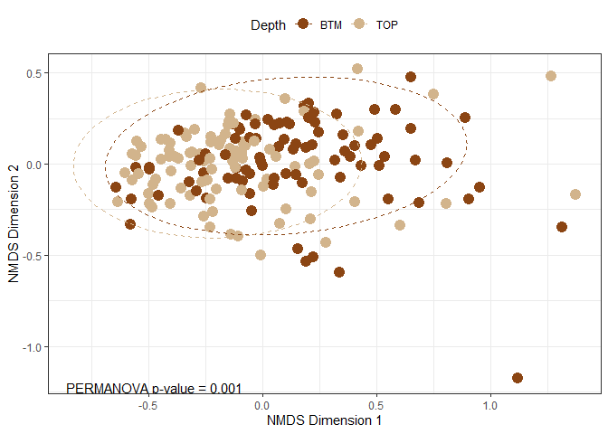

```r
nms = as.data.frame(scores(nms)) # Converting to scores
factors = mol_properties_average %>% dplyr::select(Sample_ID,Depth)
factors$Sample_Set = gsub('_BTM|_TOP','',factors$Sample_ID)
factors = merge(factors,metadata, by = 'Sample_Set')
nms = cbind(factors, nms)

#Perform PERMANOVA
depth = as.factor(nms$Depth)
permanova = adonis2(t(merged_fticr_data) ~ depth, method = "jaccard", permutations = 999)

# Extract the p-value from the PERMANOVA results
permanova_pvalue = permanova$`Pr(>F)`[1]

#Plot
plot <- nms %>%
  ggplot(aes(x = NMDS1, y = NMDS2)) +
  geom_point(aes(color = Depth), size = 4) +
  stat_ellipse(aes(color = Depth), level = 0.95, linetype = 2) +
  scale_color_manual(values = soil_colors) +
  theme_bw() +
  theme(legend.position = "top") +
  labs(
    x = "NMDS Dimension 1",
    y = "NMDS Dimension 2") +
annotate("text", x = -Inf, y = -Inf, label = paste("PERMANOVA p-value =", format.pval(permanova_pvalue)), hjust = -0.1, vjust = -0.1)

# Print the plot
print(plot)
```

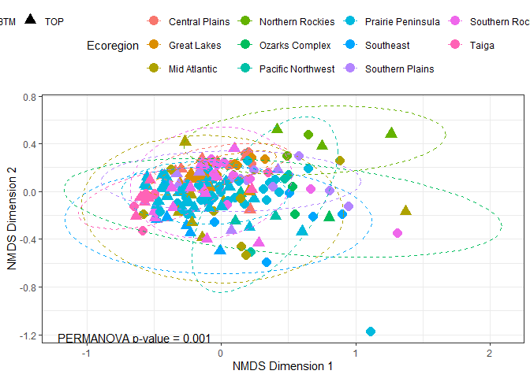

```r
plot2 <- nms %>%
  ggplot(aes(x = NMDS1, y = NMDS2)) +
  geom_point(aes(color = Ecoregion,shape = Depth), size = 4) +
  stat_ellipse(aes(color = Ecoregion), level = 0.95, linetype = 2) +
  theme_bw() +
  theme(legend.position = "top") +
  labs(
    x = "NMDS Dimension 1",
    y = "NMDS Dimension 2") +
annotate("text", x = -Inf, y = -Inf, label = paste("PERMANOVA p-value =", format.pval(permanova_pvalue)), hjust = -0.1, vjust = -0.1)

# Print the plot
print(plot2)
```

#### PCA

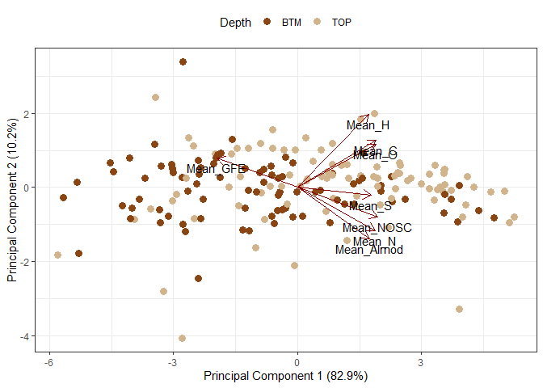

```r
chemical_data = mol_properties_average %>%
  dplyr::select(c(-Proposal_ID,-Sample_ID,-Depth, -Sample_number,-total_formulas, -Mean_P))

pca_result <- prcomp(chemical_data, scale. = TRUE)

# Create a data frame with PCA results
pca_scores <- as.data.frame(pca_result$x)
pca_loadings <- as.data.frame(pca_result$rotation)

# Add PCA scores to factors
pca_dat <- cbind(factors, pca_scores)

# Calculate the percentage of variance explained by each PC
percent_variance <- round(100 * pca_result$sdev^2 / sum(pca_result$sdev^2), 1)

# Create the PCA plot with loadings as arrows
pca_plot <- ggplot(pca_dat, aes(x = PC1, y = PC2, color = Depth)) +
  geom_point(size = 3) +
  scale_color_manual(values = soil_colors) +
  theme_bw() +
  labs( x = paste0("Principal Component 1 (", percent_variance[1], "%)"),
       y = paste0("Principal Component 2 (", percent_variance[2], "%)")) +
  theme(legend.position = "top") +
  geom_segment(data = pca_loadings, aes(x = 0, y = 0, xend = PC1 * max(pca_scores$PC1),
                                        yend = PC2 * max(pca_scores$PC2)),
               arrow = arrow(length = unit(0.3, "cm")), color = "darkred") +
  geom_text(data = pca_loadings, aes(x = PC1 * max(pca_scores$PC1),
                                     y = PC2 * max(pca_scores$PC2),
                                     label = rownames(pca_loadings)), color = "black", vjust = 1.5)

print(pca_plot)
```

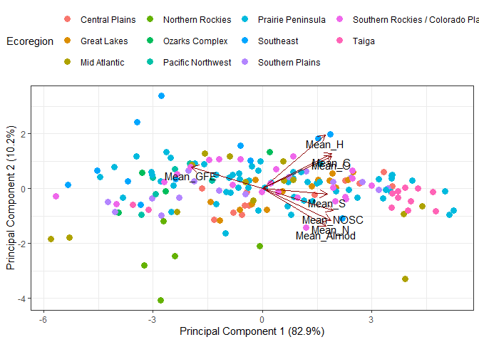

```r
pca_plot2 <- ggplot(pca_dat, aes(x = PC1, y = PC2, color = Ecoregion)) +
  geom_point(size = 3) +
  theme_bw() +
  labs( x = paste0("Principal Component 1 (", percent_variance[1], "%)"),
       y = paste0("Principal Component 2 (", percent_variance[2], "%)")) +
  theme(legend.position = "top") +
  geom_segment(data = pca_loadings, aes(x = 0, y = 0, xend = PC1 * max(pca_scores$PC1),
                                        yend = PC2 * max(pca_scores$PC2)),
               arrow = arrow(length = unit(0.3, "cm")), color = "darkred") +
  geom_text(data = pca_loadings, aes(x = PC1 * max(pca_scores$PC1),
                                     y = PC2 * max(pca_scores$PC2),
                                     label = rownames(pca_loadings)), color = "black", vjust = 1.5)

print(pca_plot2)
```

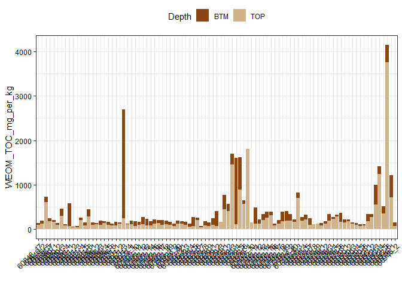

```r
biogeochem$Depth <- biogeochem$Core_Section
biogeochem = biogeochem %>%
  filter(!is.na(WEOM_TOC_mg_per_kg))

biogeochem$Sample_combination = sub("_[^_]+_[^_]+$", "", biogeochem$Sample_Name)
biogeochem$Sample_ID = sub("_[^_]+$", "", biogeochem$Sample_Name)

# Generate the boxplot
ggplot(biogeochem, aes(x = Sample_combination, y = as.numeric(`WEOM_TOC_mg_per_kg`), fill = Depth)) +
  geom_bar(stat = 'identity') +
  labs(x = '', y = "WEOM_TOC_mg_per_kg") +
  theme_bw()+
    theme(axis.text.x = element_text(angle = 45, hjust = 1, color = "black"),
        axis.text.y = element_text(color = "black"),
        axis.title.x = element_text(color = "black"),
        axis.title.y = element_text(color = "black"),
        plot.title = element_text(color = "black"),
        legend.position = "top") +
  scale_fill_manual(values = c("TOP" = "#D2B48C", "BTM" = "#8B4513"))  # Lighter brown for TOP, darker brown for BTM
```

#### Correlations

Correlation between richness(number of peaks with molecular formula assigned in a sample) and WEOM for each top and bottom.

Plotting Pearson correlations

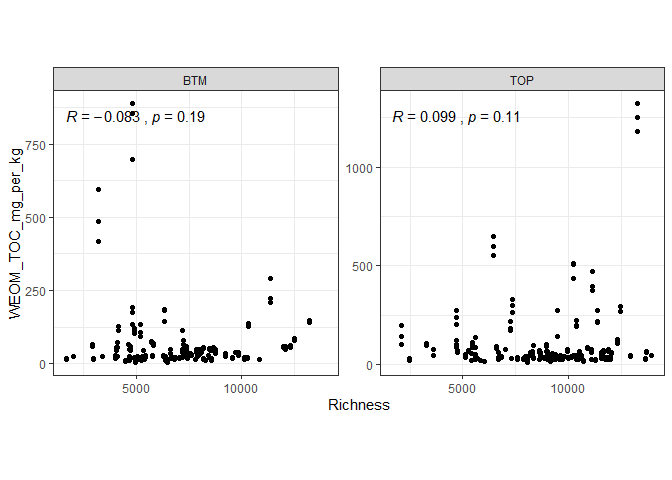

```r
data_cor = merge(mol_properties_average,biogeochem, by = c('Sample_ID','Depth'))
data_cor = data_cor %>%
  dplyr::select(Depth,total_formulas,WEOM_TOC_mg_per_kg)


ggplot(data_cor, aes(x = total_formulas, y = WEOM_TOC_mg_per_kg)) +
  geom_point() +
  facet_wrap(~ Depth, scales = 'free_y') +
  labs( x = "Richness",
       y = "WEOM_TOC_mg_per_kg") +
  theme_bw() +
    stat_cor(method = "pearson", aes(label = paste(..r.label.., ..p.label.., sep = "~`,`~")), label.x.npc = "left", label.y.npc = "top") +
 theme(aspect.ratio = 1)
```

#### Boxplot of GFE and NOSC

[LaRowe and Van Cappellen, 2012](https://www.sciencedirect.com/science/article/pii/S0016703711000378) found an empirical relationship between the Gibbs Free Energy of C oxidation at standard state (GFE) and the nominal oxidation state of C (NOSC).*Lower values of GFE (i.e., lower magnitudes are more thermodynamically favorable.)*

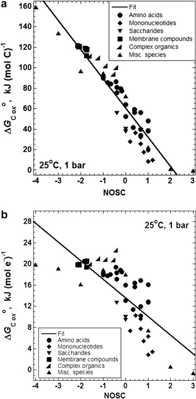

Image from LaRowe and Van Capellen 2012. Standard molal Gibbs energies of the oxidation half reactions of organic compounds as a function of the average nominal oxidation state of carbon (NOSC) in the compounds, at 25 °C and 1 bar. The Gibbs energies are expressed in kJ per mole of carbon (a) and kJ per mole of electrons transferred (b)

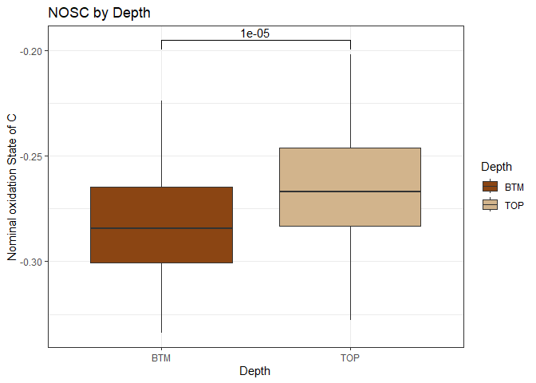

```r
# Create the boxplot of mean values with statistical test
# NOSC
ggplot(mol_properties_average, aes(x = Depth, y = as.numeric(Mean_NOSC), fill = Depth)) +
  geom_boxplot() +
  labs(
    title = "NOSC by Depth",
    x = "Depth",
    y = "Nominal oxidation State of C"
  ) +
  theme_bw() +
  scale_fill_manual(values = soil_colors) +
  stat_compare_means(comparisons = list(c("TOP", "BTM")), method = "t.test", label = "p.format")
```

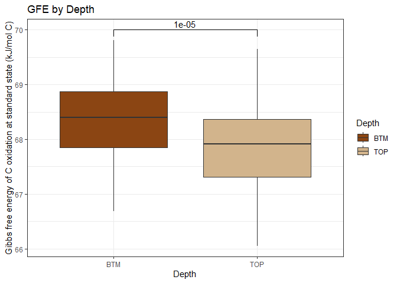

```r
# GFE
ggplot(mol_properties_average, aes(x = Depth, y = as.numeric(Mean_GFE), fill = Depth)) +
  geom_boxplot() +
  labs(
    title = "GFE by Depth",
    x = "Depth",
    y = "Gibbs free energy of C oxidation at standard state (kJ/mol C)"
  ) +
  theme_bw() +
  scale_fill_manual(values = soil_colors) +
  stat_compare_means(comparisons = list(c("TOP", "BTM")), method = "t.test", label = "p.format")
```

#### WEOM Boxplots

Looking at water extractable C across depths

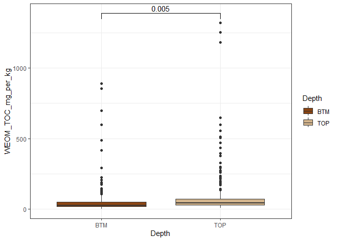

```r
# Create the main plot with zoom
main_plot <- ggplot(biogeochem, aes(x = Depth, y = WEOM_TOC_mg_per_kg, fill = Depth)) +
  geom_boxplot() +
  labs(
    x = "Depth",
    y = "WEOM_TOC_mg_per_kg"
  ) +
  scale_fill_manual(values = soil_colors) +
  theme_bw() +
  stat_compare_means(comparisons = list(c("TOP", "BTM")), method = "t.test", label = "p.format")

print(main_plot)
```